# Replicate the Pitch Arsenal application

**Yilun Fu**

The CSV files related to the processed datasets: https://uofi.box.com/s/yuze8ig3qhd36v9suzmc4cew246l05n0

## Section 1: Dataset description

For this project, we will work with the data provided by the pybaseball package, which focuses on baseball data analysis. The package retrieves statcast data, pitching, batting, and team statistics, etc. In total, there are 557 rows and 334 columns in the dataset. I list some of the variables that might be useful.

- 1.player_name: Player's name tied to the event of the search.
- 2.pitcher: MLB Player Id tied to the play event.
- 3.p_throws: Hand pitcher throws with.
- 3.release_pos_x: Horizontal Release Position of the ball measured in feet from the catcher's perspective.
- 4.release_pos_z: Vertical Release Position of the ball measured in feet from the catcher's perspective.
- 5.release_speed: Pitch velocities from 2008-16 are via Pitch F/X, and adjusted to roughly out-of-hand release point. All velocities from 2017 and beyond are Statcast, which are reported out-of-hand.
- 6.pitch_type: The type of pitch derived from Statcast.
- 7.game_date: Date of the Game.

```python
from pybaseball import pitching_stats
data = pitching_stats(2008, qual=10)
data
```

|  | IDfg | Season | Name | Team | Age | W | L | WAR | ERA | G | ... | LA | Barrels | Barrel% | maxEV | HardHit | HardHit% | Events | CStr% | CSW% | xERA |
| --- | --- | --- | --- | --- | --- | --- | --- | --- | --- | --- | --- | --- | --- | --- | --- | --- | --- | --- | --- | --- | --- |
| 65 | 404 | 2008 | CC Sabathia | - - - | 27 | 17 | 10 | 7.4 | 2.70 | 35 | ... | NaN | 0 | NaN | NaN | 0 | NaN | 0 | 0.162 | 0.302 | NaN |
| 56 | 5705 | 2008 | Tim Lincecum | SFG | 24 | 18 | 5 | 7.1 | 2.62 | 34 | ... | NaN | 0 | NaN | NaN | 0 | NaN | 0 | 0.170 | 0.288 | NaN |
| 49 | 1636 | 2008 | Cliff Lee | CLE | 29 | 22 | 3 | 6.8 | 2.54 | 31 | ... | NaN | 0 | NaN | NaN | 0 | NaN | 0 | 0.193 | 0.274 | NaN |
| 69 | 1303 | 2008 | Roy Halladay | TOR | 31 | 20 | 11 | 6.7 | 2.78 | 34 | ... | NaN | 0 | NaN | NaN | 0 | NaN | 0 | 0.164 | 0.256 | NaN |
| 120 | 1757 | 2008 | Dan Haren | ARI | 27 | 16 | 8 | 6.1 | 3.33 | 33 | ... | NaN | 0 | NaN | NaN | 0 | NaN | 0 | 0.185 | 0.285 | NaN |
| ... | ... | ... | ... | ... | ... | ... | ... | ... | ... | ... | ... | ... | ... | ... | ... | ... | ... | ... | ... | ... | ... |
| 416 | 650 | 2008 | Eric Gagne | MIL | 32 | 4 | 3 | -0.9 | 5.44 | 50 | ... | NaN | 0 | NaN | NaN | 0 | NaN | 0 | 0.156 | 0.272 | NaN |
| 368 | 451 | 2008 | Justin Speier | LAA | 34 | 2 | 8 | -0.9 | 5.03 | 62 | ... | NaN | 0 | NaN | NaN | 0 | NaN | 0 | 0.179 | 0.268 | NaN |
| 499 | 502 | 2008 | Jamie Walker | BAL | 36 | 1 | 3 | -0.9 | 6.87 | 59 | ... | NaN | 0 | NaN | NaN | 0 | NaN | 0 | 0.172 | 0.269 | NaN |
| 367 | 1654 | 2008 | Oscar Villarreal | HOU | 26 | 1 | 3 | -1.0 | 5.02 | 35 | ... | NaN | 0 | NaN | NaN | 0 | NaN | 0 | 0.152 | 0.234 | NaN |
| 477 | 46 | 2008 | Miguel Batista | SEA | 37 | 4 | 14 | -1.3 | 6.26 | 44 | ... | NaN | 0 | NaN | NaN | 0 | NaN | 0 | 0.163 | 0.232 | NaN |

557 rows × 334 columns

## Section 2: Question of interest

My goal for the dash web is when I change 'Season' button, the values for RHP(right hand pitcher) and LHP(left hand pitcher) are updated. Also, only one pitcher can be selected at one time (one value selected in either RHP or LHP).

- The optimal figure shows the pitch_name(such as Slider/4-Seam Fastball, etc.) and percentage corresponding to the player we choose.
- Shows a figure related to pitch_name and release_speed.
- Shows a figure about the release_pos.

## Section 3: Testing of the web app

I choose the 'Season' to be '2020' and 'LHP' to be 'Canning, Griffin'. The the web shows three figures as assumed. All the three work greatly with no error. For example, these figures show that 4-Seam Fastball Canning made in 2020 is 40.6218% with 92.8mph.

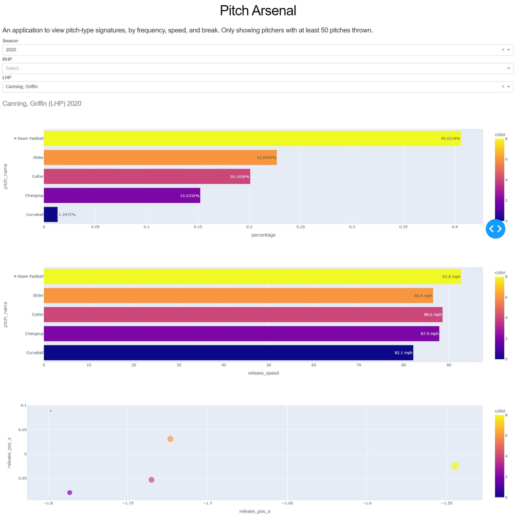

```python
from IPython.display import Image
Image(filename = 'C:/Users/lun/Desktop/STAT430/yilunf2/Final project/dash_web/final/Test/123.jpeg')
```

Then we can test for another time. Setting 'Season' to be '2018' and 'RHP' to be 'Freeland, Kyle', we get the result related to this player.

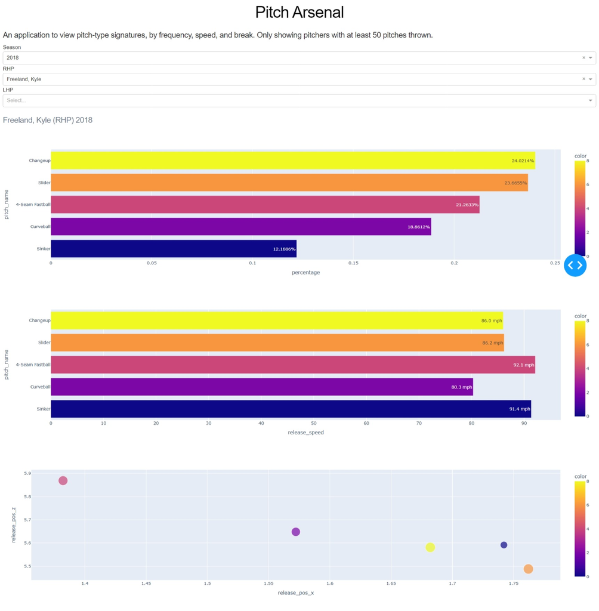

```python
from IPython.display import Image
Image(filename = 'C:/Users/lun/Desktop/STAT430/yilunf2/Final project/dash_web/final/Test/345.jpeg')
```

## Section 4: Conclusion & discussion

I think the descriptions toward a certain RHP or LHP are clearly presented in a given year. Also, very clear to have a look at. The interest listed in previous are all met. If someone is to continue working on my project, I think maybe he/she can try to combine my figure1 and figure2 together.